# The Great Bean Experiment!

Joe Nese and EDLD 651

9/29/2021

**Introduction**

This is the great bean experiment! An under-powered (mediocre) scientific replication of the famous historical event (folktale?) in statistics in which each person in town was asked to guess the weight of the ox. Having no knowledge of oxen, no person correctly guessed the weight, but the average of all guesses was within one pound of the ox’s weight! What an inspiring story of collectivism, the strength in numbers, and the power of data, data science, and statistics! We are better together.

**Method**

We used the following packages: equatiomatic (Anderson, ND), ggrepel Slowikowski (2021), ggthemes Arnold (2021), here Müller (2020), knitr Xie (2014), parameters Lüdecke et al. (2020), reactable Lin (2020), and tidyverse Wickham et al. (2019).

**Research Question**

1. Is the average of the class’s bean guesses closer to the actual number of beans in the jar than any one person?

Our hypothesis is that the class average will be more accurate than the guess of any one person.

**Results**

First, let’s look at a density plot, which shows the distribution of the class guesses.

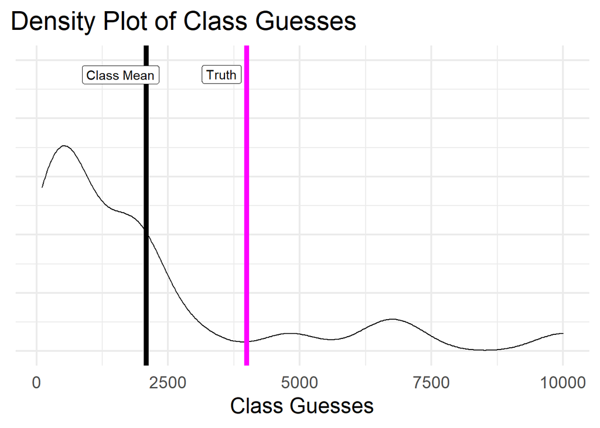

And here is a table of the class guesses. You can filter and sort it!

| first | guess |
| --- | --- |
| Elizabeth | 341 |
| Lauren | 373 |
| Esmeralda | 372 |
| Yijun | NA |
| Adriana | 577 |
| Eliott | 3000 |
| Zach | 1776 |
| Mavis | 480 |
| Aubrey | 450 |
| Claire | 744 |

[output cut: 19 more lines]

Here is another cool data visualization.

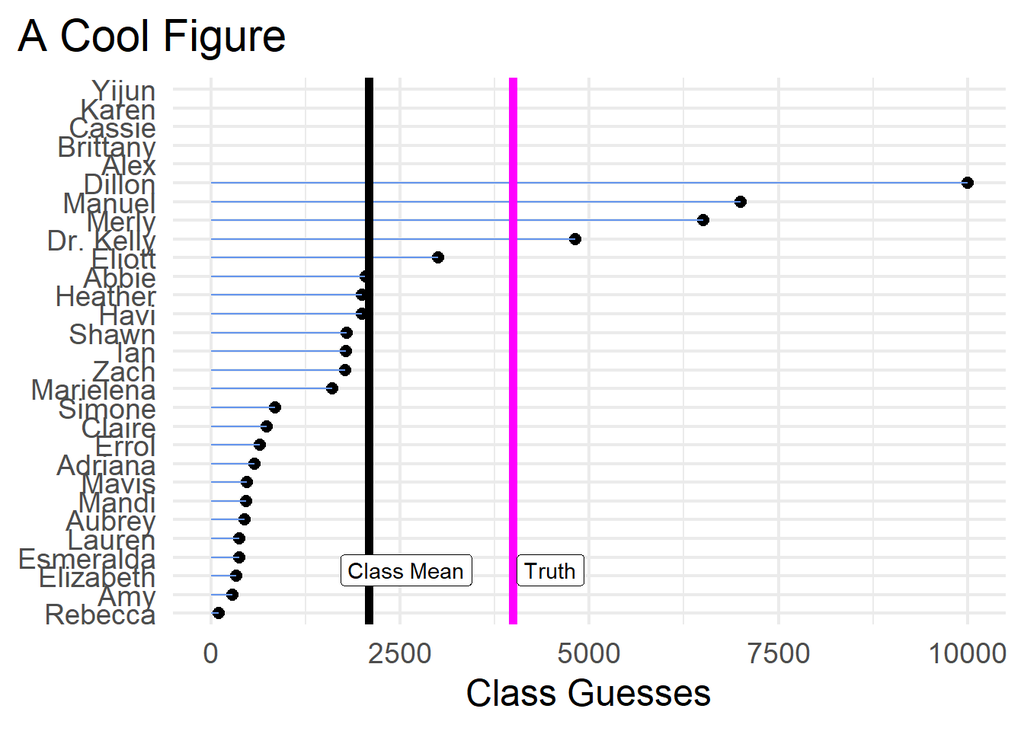

Or perhaps my favorite:

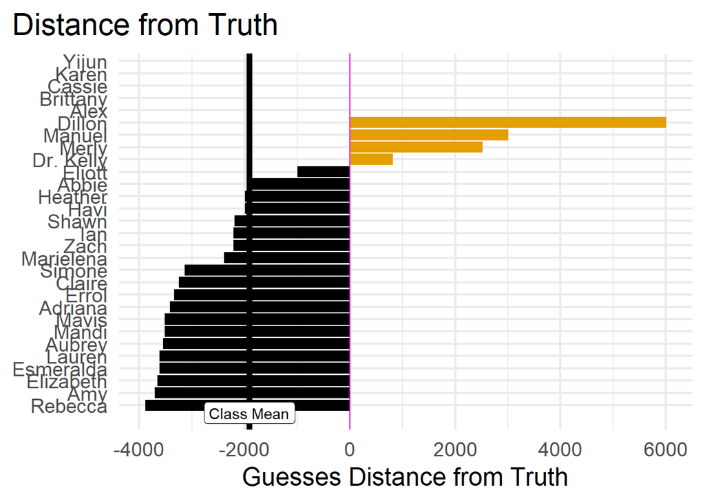

Now let’s get to the results…

The actual number of beans in the jar was **3,992**.

So to answer our research question…

**Hypthosis rejected! Dr. Kelly’s guess was closer than the class average! Replication crisis?**

**Discussion**

Wait! I’m having fun with this, so let’s look at major and ID number!

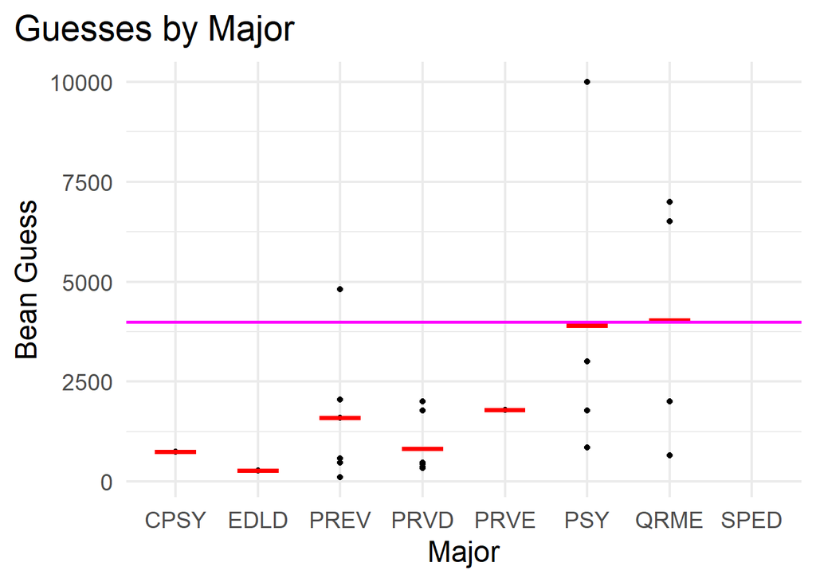

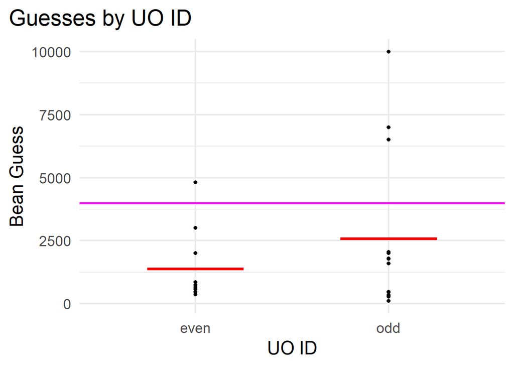

Let’s run (bad) a regression! With some some help from the `{equatiomatic}` package by our own [Daniel Anderson](https://github.com/datalorax/equatiomatic)!

$$\begin{aligned}
\operatorname{dist} &= \alpha + \beta_{1}(\operatorname{major}_{\operatorname{EDLD}}) + \beta_{2}(\operatorname{major}_{\operatorname{PREV}}) + \beta_{3}(\operatorname{major}_{\operatorname{PRVD}})\ + \\
&\quad \beta_{4}(\operatorname{major}_{\operatorname{PRVE}}) + \beta_{5}(\operatorname{major}_{\operatorname{PSY}}) + \beta_{6}(\operatorname{major}_{\operatorname{QRME}}) + \beta_{7}(\operatorname{id}_{\operatorname{odd}})\ + \\
&\quad \epsilon
\end{aligned}$$

These are the Regression Results

| Parameter | Coefficient | SE | CI_low | CI_high | p |
| --- | --- | --- | --- | --- | --- |
| (Intercept) | -3248.0 | 2434.5 | -8408.9 | 1912.9 | 0.201 |
| majorEDLD | -1555.5 | 3617.9 | -9225.0 | 6114.0 | 0.673 |
| majorPREV | 128.0 | 2732.0 | -5663.5 | 5919.5 | 0.963 |
| majorPRVD | -386.1 | 2645.8 | -5994.9 | 5222.8 | 0.886 |
| majorPRVE | -39.5 | 3617.9 | -7709.0 | 7630.0 | 0.991 |
| majorPSY | 2616.3 | 2778.0 | -3272.8 | 8505.4 | 0.360 |
| majorQRME | 2474.7 | 2846.6 | -3559.9 | 8509.2 | 0.398 |
| idodd | 1095.5 | 1111.5 | -1260.7 | 3451.7 | 0.339 |

**References**

Arnold, Jeffrey B. 2021. *Ggthemes: Extra Themes, Scales and Geoms for ’Ggplot2’*. https://CRAN.R-project.org/package=ggthemes.

Lin, Greg. 2020. *Reactable: Interactive Data Tables Based on ’React Table’*. https://CRAN.R-project.org/package=reactable.

Lüdecke, Daniel, Mattan S. Ben-Shachar, Indrajeet Patil, and Dominique Makowski. 2020. “Extracting, Computing and Exploring the Parameters of Statistical Models Using R.” *Journal of Open Source Software* 5 (53): 2445. https://doi.org/10.21105/joss.02445.

Müller, Kirill. 2020. *Here: A Simpler Way to Find Your Files*. https://CRAN.R-project.org/package=here.

Slowikowski, Kamil. 2021. *Ggrepel: Automatically Position Non-Overlapping Text Labels with ’Ggplot2’*. https://CRAN.R-project.org/package=ggrepel.

Wickham, Hadley, Mara Averick, Jennifer Bryan, Winston Chang, Lucy D’Agostino McGowan, Romain François, Garrett Grolemund, et al. 2019. “Welcome to the tidyverse.” *Journal of Open Source Software* 4 (43): 1686. https://doi.org/10.21105/joss.01686.

Xie, Yihui. 2014. “Knitr: A Comprehensive Tool for Reproducible Research in R.” In *Implementing Reproducible Computational Research*, edited by Victoria Stodden, Friedrich Leisch, and Roger D. Peng. Chapman; Hall/CRC. http://www.crcpress.com/product/isbn/9781466561595.